# Introduction

## Jungle

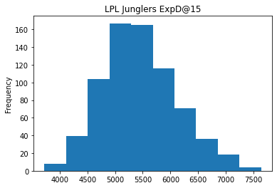

```python
lpl_jng_data.xpat15.plot(title='LPL Junglers ExpD@15', kind='hist');
```

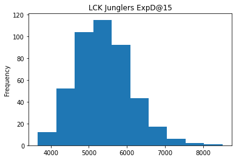

```python
lck_jng_data.xpat15.plot(title='LCK Junglers ExpD@15', kind='hist');
```

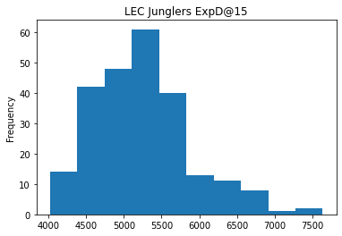

```python
lec_jng_data.xpat15.plot(title='LEC Junglers ExpD@15', kind='hist');
```

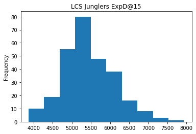

```python
lcs_jng_data.xpat15.plot(title='LCS Junglers ExpD@15', kind='hist');
```

## Middle

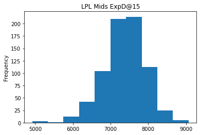

```python
lpl_mid_data.xpat15.plot(title='LPL Mids ExpD@15', kind='hist');
```

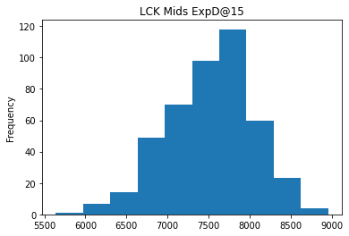

```python
lck_mid_data.xpat15.plot(title='LCK Mids ExpD@15', kind='hist');
```

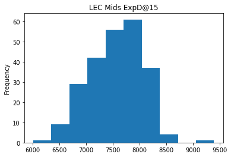

```python
lec_mid_data.xpat15.plot(title='LEC Mids ExpD@15', kind='hist');
```

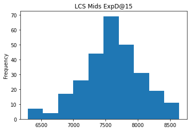

```python
lcs_mid_data.xpat15.plot(title='LCS Mids ExpD@15', kind='hist');
```

## ADC's

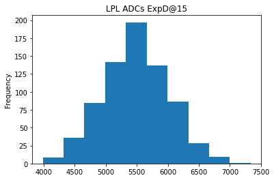

```python
lpl_bot_data.xpat15.plot(title='LPL ADCs ExpD@15', kind='hist');
```

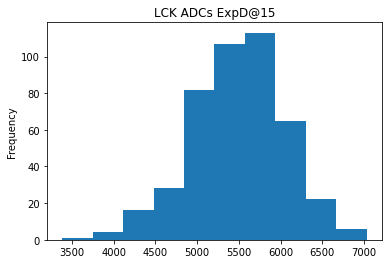

```python
lck_bot_data.xpat15.plot(title='LCK ADCs ExpD@15', kind='hist');
```

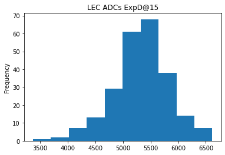

```python
lec_bot_data.xpat15.plot(title='LEC ADCs ExpD@15', kind='hist');
```

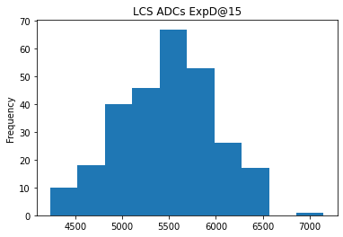

```python
lcs_bot_data.xpat15.plot(title='LCS ADCs ExpD@15', kind='hist');
```

## Support

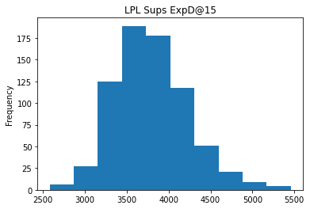

```python
lpl_sup_data.xpat15.plot(title='LPL Sups ExpD@15', kind='hist');
```

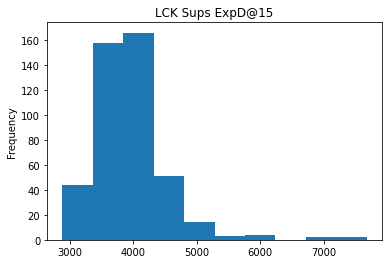

```python
lck_sup_data.xpat15.plot(title='LCK Sups ExpD@15', kind='hist');
```

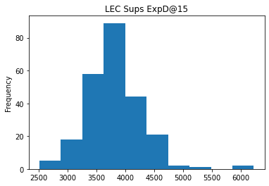

```python
lec_sup_data.xpat15.plot(title='LEC Sups ExpD@15', kind='hist');
```

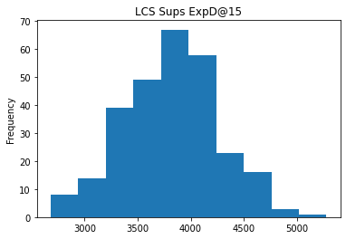

```python
lcs_sup_data.xpat15.plot(title='LCS Sups ExpD@15', kind='hist');
```

## My thoughts

Don't really have much to talk about in this case. I left these code blocks in as they were part of my initial exploration but there wasn't much I was able to glean on my end. I am leaving these distributions in for the purposes of my reader as perhaps they could be of some value to someone who offers a unique perspective that an amateur hobbyist like me might not be able to.

# EarnedGoldShare Broken Down by Role

## TOP

```python
print("LPL Top Laner Earned Gold Share: %f%%" %(lpl_top_data.earnedgoldshare.mean() * 100.0))
print("LCK Top Laner Earned Gold Share: %f%%" %(lck_top_data.earnedgoldshare.mean() * 100.0))
print("LEC Top Laner Earned Gold Share: %f%%" %(lec_top_data.earnedgoldshare.mean() * 100.0))
print("LCS Top Laner Earned Gold Share: %f%%" %(lcs_top_data.earnedgoldshare.mean() * 100.0))
```

```
LPL Top Laner Earned Gold Share: 22.323394%
LCK Top Laner Earned Gold Share: 23.006989%
LEC Top Laner Earned Gold Share: 22.047035%
LCS Top Laner Earned Gold Share: 22.273917%
```

## JUNGLE

```python
print("LPL Jng Laner Earned Gold Share: %f%%" %(lpl_jng_data.earnedgoldshare.mean() * 100.0))
print("LCK Jng Laner Earned Gold Share: %f%%" %(lck_jng_data.earnedgoldshare.mean() * 100.0))
print("LEC Jng Laner Earned Gold Share: %f%%" %(lec_jng_data.earnedgoldshare.mean() * 100.0))
print("LCS Jng Laner Earned Gold Share: %f%%" %(lcs_jng_data.earnedgoldshare.mean() * 100.0))
```

```
LPL Jng Laner Earned Gold Share: 18.560981%
LCK Jng Laner Earned Gold Share: 17.354866%
LEC Jng Laner Earned Gold Share: 16.981444%
LCS Jng Laner Earned Gold Share: 18.187359%
```

## MIDDLE

```python
print("LPL Mid Laner Earned Gold Share: %f%%" %(lpl_mid_data.earnedgoldshare.mean() * 100.0))
print("LCK Mid Laner Earned Gold Share: %f%%" %(lck_mid_data.earnedgoldshare.mean() * 100.0))
print("LEC Mid Laner Earned Gold Share: %f%%" %(lec_mid_data.earnedgoldshare.mean() * 100.0))
print("LCS Mid Laner Earned Gold Share: %f%%" %(lcs_mid_data.earnedgoldshare.mean() * 100.0))
```

```
LPL Mid Laner Earned Gold Share: 23.409528%
LCK Mid Laner Earned Gold Share: 23.953635%
LEC Mid Laner Earned Gold Share: 25.724058%
LCS Mid Laner Earned Gold Share: 24.867707%
```

## BOTTOM

```python
print("LPL Bot Laner Earned Gold Share: %f%%" %(lpl_bot_data.earnedgoldshare.mean() * 100.0))
print("LCK Bot Laner Earned Gold Share: %f%%" %(lck_bot_data.earnedgoldshare.mean() * 100.0))
print("LEC Bot Laner Earned Gold Share: %f%%" %(lec_bot_data.earnedgoldshare.mean() * 100.0))
print("LCS Bot Laner Earned Gold Share: %f%%" %(lcs_bot_data.earnedgoldshare.mean() * 100.0))
```

```
LPL Bot Laner Earned Gold Share: 26.661608%
LCK Bot Laner Earned Gold Share: 26.512805%
LEC Bot Laner Earned Gold Share: 26.437188%
LCS Bot Laner Earned Gold Share: 26.157581%
```

## SUPPORT

```python
print("LPL Sup Laner Earned Gold Share: %f%%" %(lpl_sup_data.earnedgoldshare.mean() * 100.0))
print("LCK Sup Laner Earned Gold Share: %f%%" %(lck_sup_data.earnedgoldshare.mean() * 100.0))
print("LEC Sup Laner Earned Gold Share: %f%%" %(lec_sup_data.earnedgoldshare.mean() * 100.0))
print("LCS Sup Laner Earned Gold Share: %f%%" %(lcs_sup_data.earnedgoldshare.mean() * 100.0))
```

```
LPL Sup Laner Earned Gold Share: 9.044488%
LCK Sup Laner Earned Gold Share: 9.171705%
LEC Sup Laner Earned Gold Share: 8.810275%
LCS Sup Laner Earned Gold Share: 8.513438%
```